# Homework 2

Elena Kharitonova, Brooke Felsheim, Ellen Risemberg

6/9/2022

# HLC Homework 2: Plotting

For the second homework, your goal will to replicate the below plot to the best of your ability using the `gapminder` data frame and `ggplot2`.

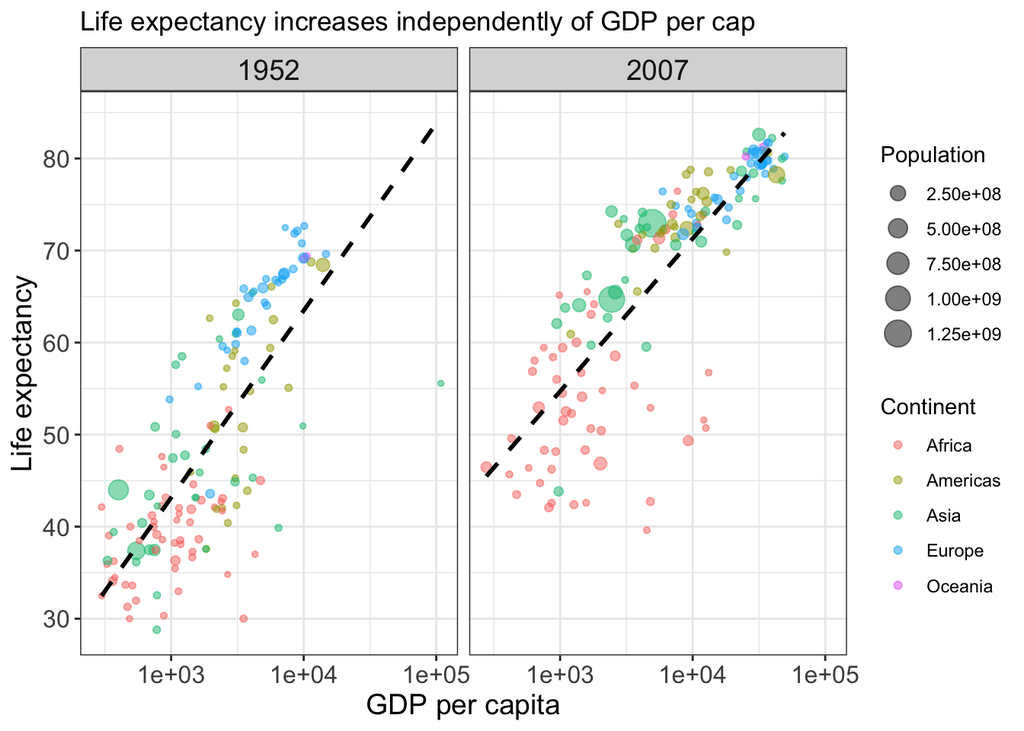

This plot is more complicated than any of the examples we have shown during class, so we will provide hints and walk through how to replicate it in steps.

In addition to the hints that will be given, make use of your resources from the HLC markdown documents we have gone over in class, [R for data science](https://r4ds.had.co.nz/data-visualisation.html), and Google. Remember that you can access the R documentation for any function by typing `?` before the name of the function in the R console, or by searching for the function in the search box of the “Help” tab of the bottom right corner of R Studio.

## Steps for creating the plot

### Step 1

Create your own new R markdown document (.Rmd file) or R script (.R file) to run the code for this homework response. If you are using a .Rmd file, remember that you must run R code in the gray code blocks. We went over how to create these during class.

### Step 2

Load the `gapminder` and `ggplot2` package contents into R. Remember that to load package contents into R, we use the `library` function.

### Step 3

Run the below code to subset of the Gapminder data for the years 1952 and 2007. This will be the data frame that you supply to `ggplot()` in later steps. We will cover subsetting data frames in more detail next week.

```r
homeworkData <- dplyr::filter(gapminder, year %in% c(1952, 2007))
```

### Step 4

We will be plotting life expectancy (`lifeExp`) vs GDP per capita (`gdpPercap`) for this data. Start by replicating the below plot, referencing the examples we covered during class as needed.

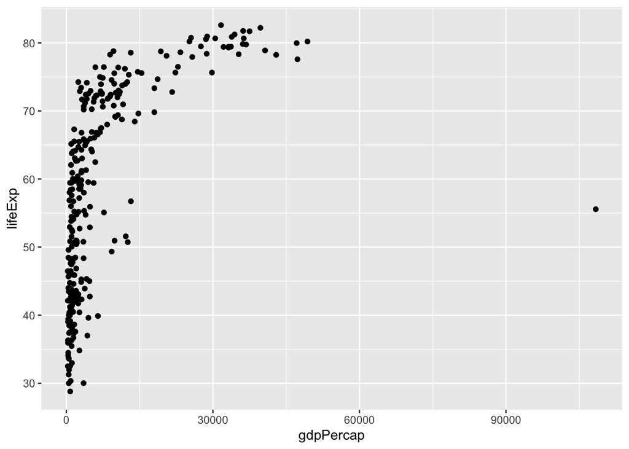

### Step 5

Now, let’s color the points by continent and scale the size of the points by population. Again, reference the examples where we did this in class as needed.

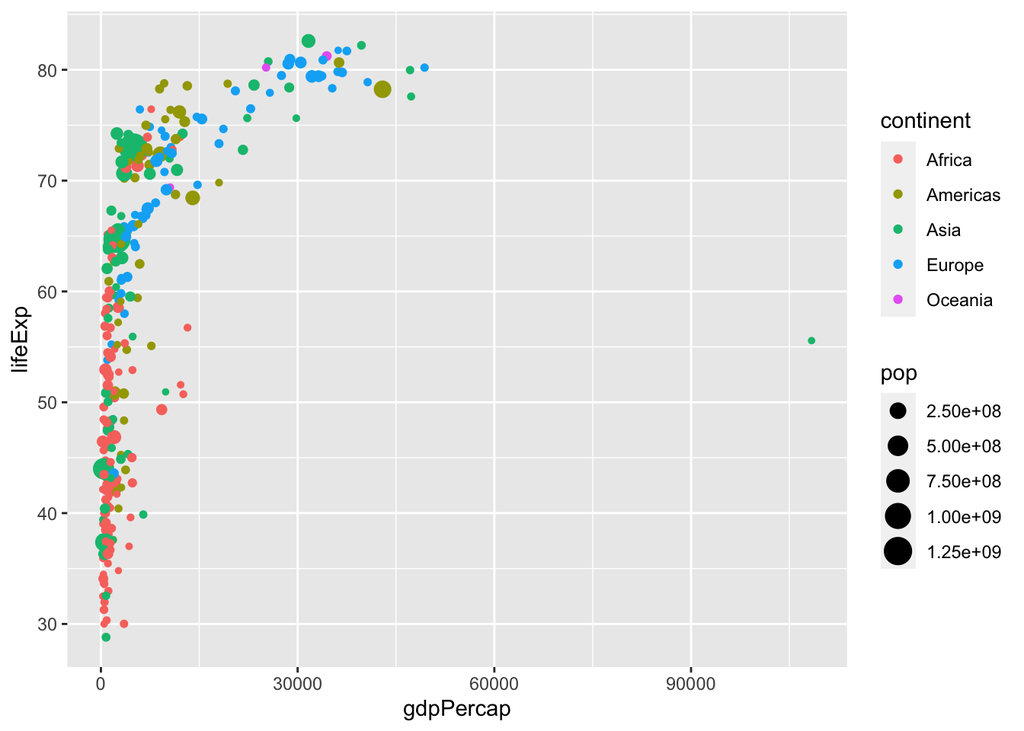

### Step 6

Notice that many of the points are overlapping each other. If we would like to see where points overlap, we can alter the transparency with the `alpha` parameter. `alpha` is a value that ranges from 0 (fully transparent) to 1 (fully opaque). In the `geom_point()` part of your code, supply `alpha = 0.5` outside of the mapping `aes()` specification. Your plot should now look like the one below.

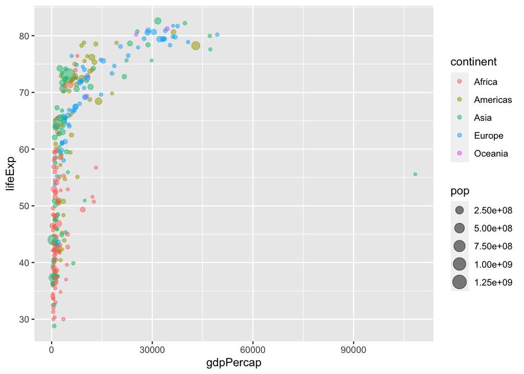

### Step 7

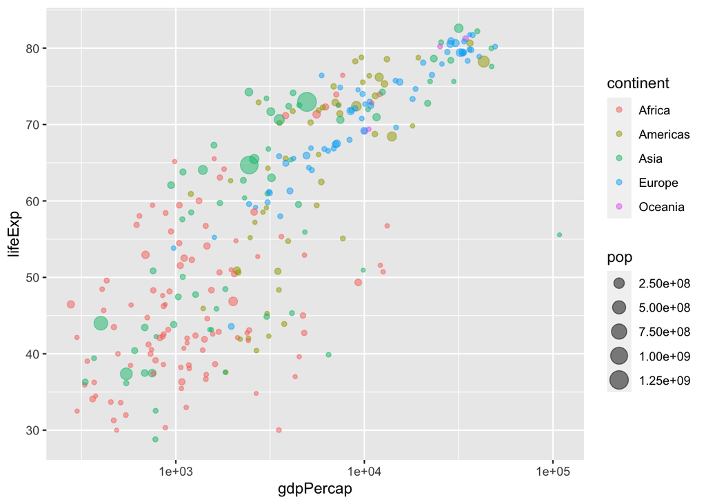

### Step 8

It looks like there is a linear trend between life expectancy and GDP per capita. We can add a linear trendline to our plot to show this relationship. To do this, we will want to make use of the `geom_smooth` function. You can read more about how to use `geom_smooth` to plot a linear trendline [here](https://www.statology.org/ggplot-trendline/) and by looking at the R documentation for this function. Bonus: hide the shaded confidence region with the `se` parameter, change the line color to black, and set the line type to be dashed.

Your plot will now look like this:

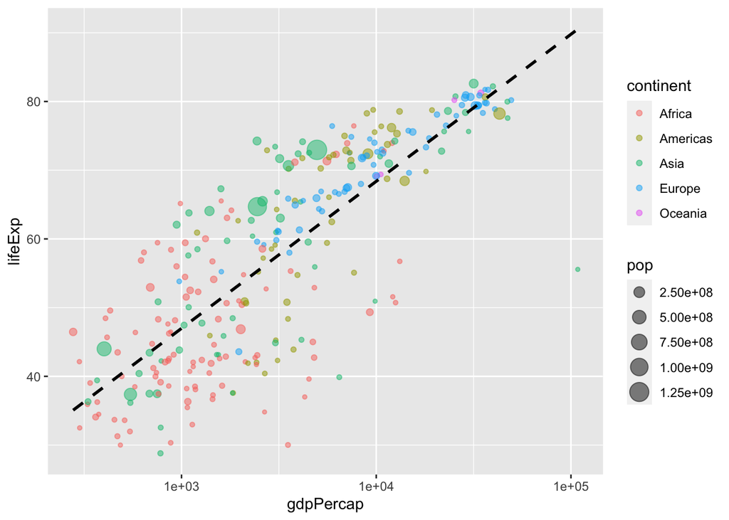

You may get a message in R that says: `geom_smooth() using formula 'y ~ x'`. You can ignore this.

### Step 9

Notice that all of our labels by default are using the column name. We want to make these more descriptive. Let’s change the x-axis label to “GDP per capita” and the y-axis label to “Life expectancy”. Let’s also add a title that says “Life expectancy increases independently of GDP per cap”. We discussed how to do this in class.

We also would like to change the legend labels to “Continent” and “Population”. Hint: there are three different ways to do this described [here](https://r-charts.com/ggplot2/legend/#title).

Your plot should now look like this:

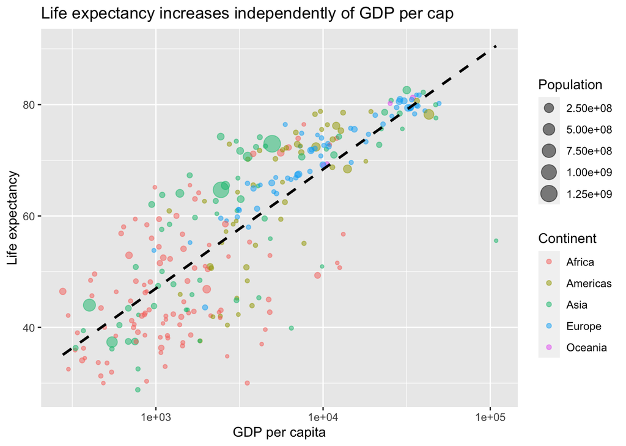

### Step 10

If you remember from the beginning, we filtered the `gapminder` data set to only contain data from the years 1952 and 2007. We want to see if the trend of life expectancy by GDP per capita is different between these two years by plotting the data for each year side-by-side. We can do this by using `facets` to show the different years. We haven’t covered this in class, but try looking at the R help page for the `facet_wrap` function to make your plot look like the one below:

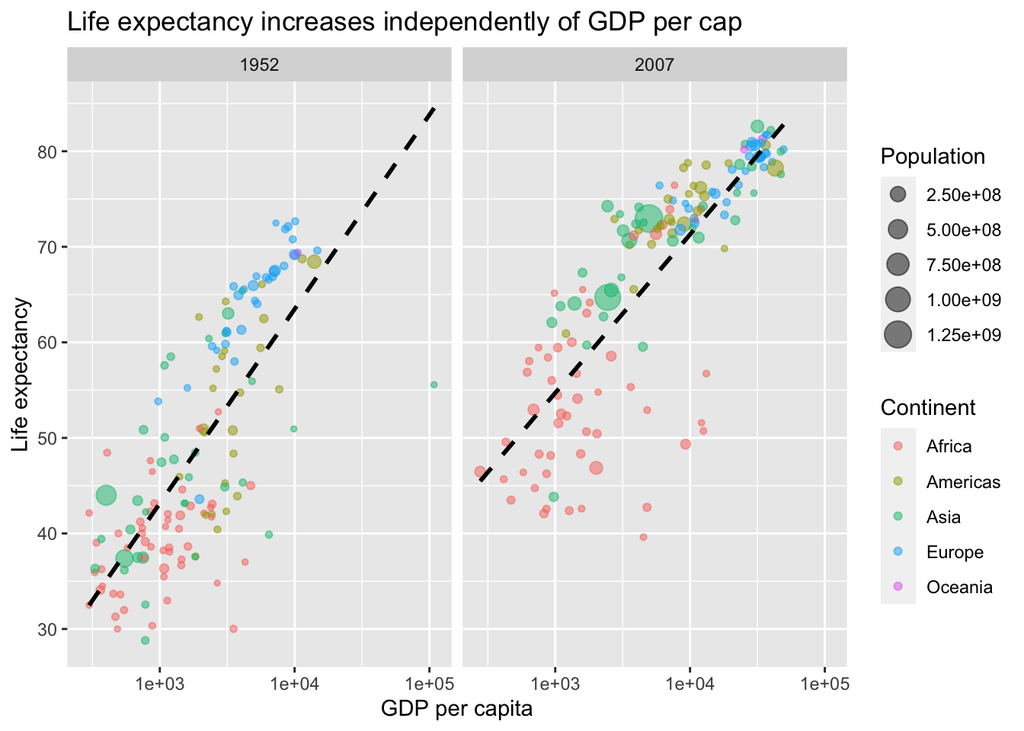

### Step 11

`ggplot2` has a theme system which allows you to have control over the non-data elements of your plot such as ticks, panel strips, and backgrounds. Themes can help you make the plot aesthetically pleasing or match an existing style guide. By default, `ggplot2` uses a theme called `theme_grey()`. This theme gives us the gray background we’ve been seeing in our plot. We can change this theme to any one of the `ggplot2` inbuilt complete themes which controll all non-data display.

Try experimenting with the theme. Run `?theme_grey` in the R console to see a help page with the complete list of theme options.

To match the plot below, change the theme to `theme_bw()`.

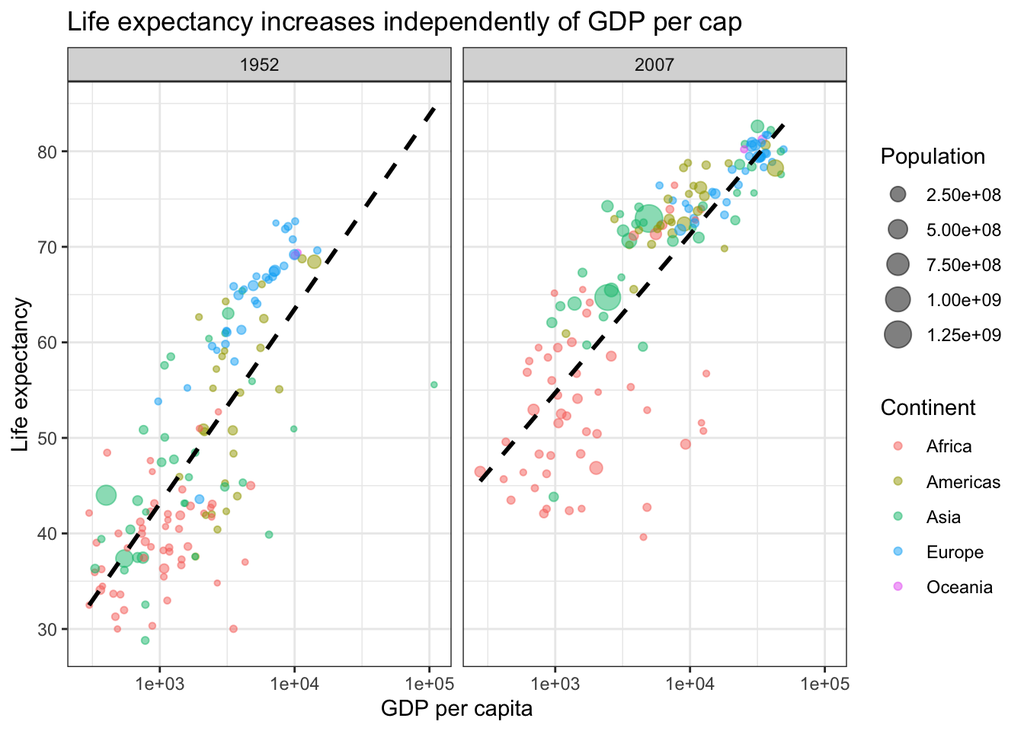

### Step 12

Finally, we can use the `theme()` function if we want to tweak components of our existing theme. One common component that you may want to change is the text size. Add the below code to your ggplot to resize the axis text to 12, the axis title text to 14, and the facet title text to 14.

```
theme(strip.text.x = element_text(size = 14),
        axis.text = element_text(size = 12),
        axis.title = element_text(size = 14))
```

Your plot should now look like this:

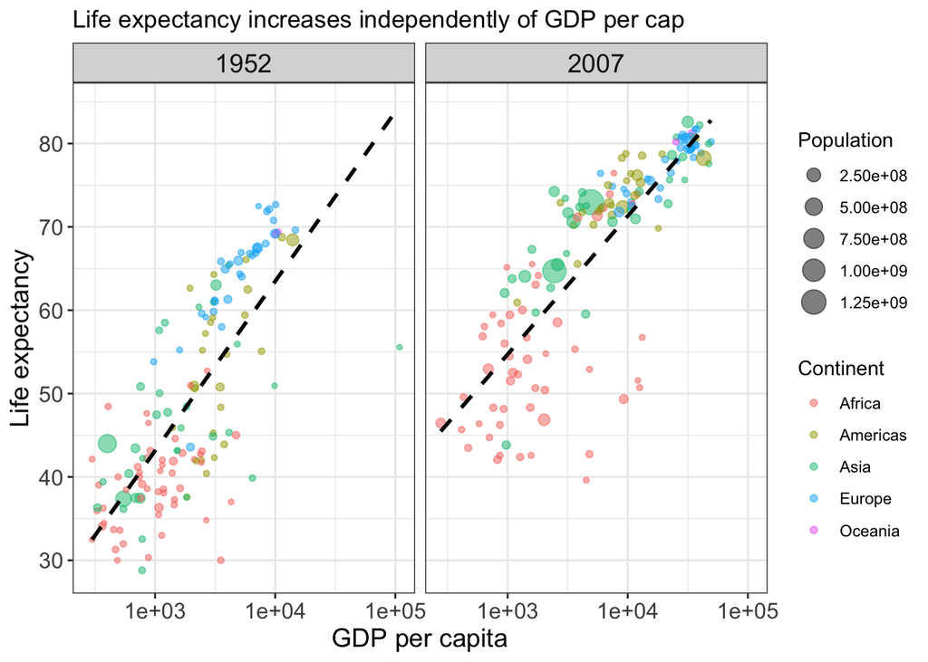

Your plot should now match the one at the beginning of the document! If you couldn’t get everything to match perfectly, don’t worry. We will go over this in class on Tuesday.